# Nucleare per combattere il cambiamento climatico

Tommaso Cleani

# Da dove arrivano le **emissioni di gas a effetto serra** a livello globale?

[figure not shown]

# Produzione di energia

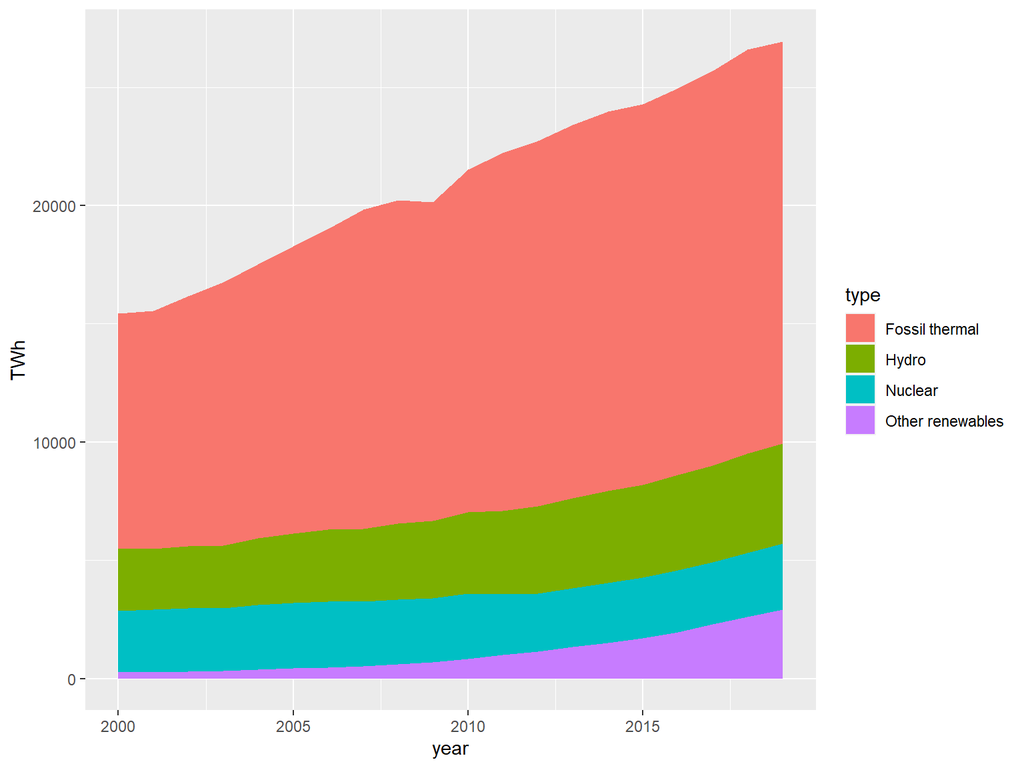

Granparte dell’energia prodotta deriva da **combustibili fossi**, i quali immettono nell’atmosfera una quantità enorme di **sostanze inquinanti**, come si può notare nel grafico negli ultimi anni l’utilizzo delle energie rinnovabili ha avuto un forte aumento, tuttavia non si è ancora raggiunto un livello tecnologico tale da sostituire totalmente le centrali che utilizzano fonti non rinnovabili.

# Qual è la migliore da utilizzare?

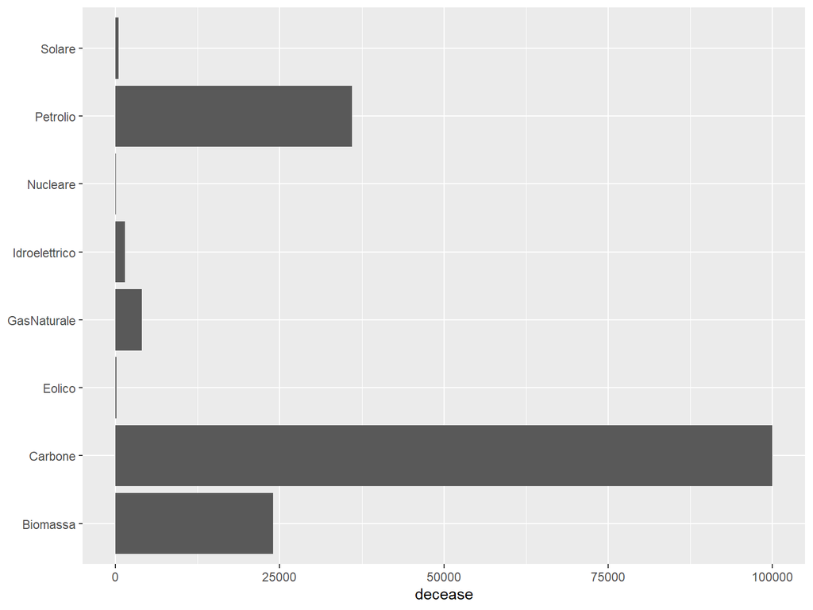

**Solare**, **idroelettrico**, **eolico** e **nucleare** sono le fonti che hanno meno morti per TWh prodotto.  
Prendendo in considerazione solo le fonti rinnovabili, l’idroelettrico durante tutto il suo ciclo di vita emette circa 34 t di CO2 per GWh prodotto. Solare, eolico e nucleare invece emetto rispettivamente 5, 4 e 3 t di CO2 per GWh prodotto.  
Quindi dai dati emerge che il nucleare sia la fonte migliore da utilizzare.

# Il nucleare è sicuro?

# Incidenti negli ultimi 50 anni

[figure not shown]

# Realizzabilità

Bill Gates in collaborazione con la startup TerraPower vuole realizzare entro il 2050 delle mini centrali nucleari per sopperire alle mancanze delle altre fonti di energia rinnovabile, facendo ciò si riuscirà a sostituire completamente le centrali a carbone o a gasolio.

Questo reattore ha un’efficienza di 4 volte maggiore rispetto alle altre fonti rinnovabili ad un costo minore

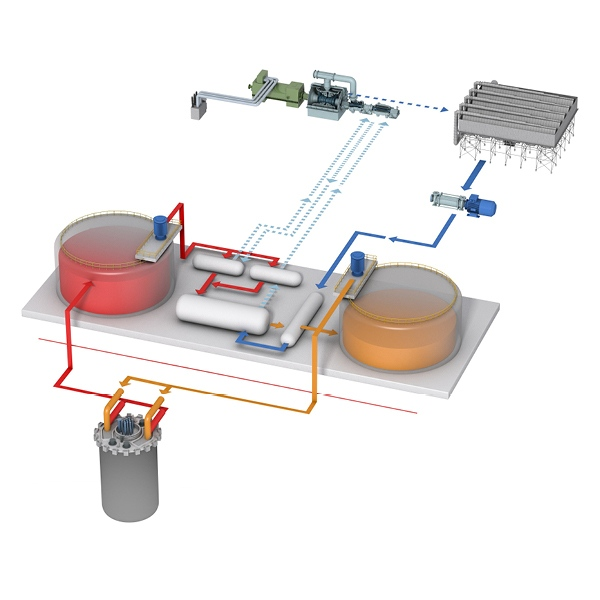

# Fonti

https://www.legambiente.it/sites/default/files/docs/Incidenti_nucleari_degli_ultimi_50_anni.0000002415.pdf https://ourworldindata.org/ https://www.eni.com/it-IT/ricerca-scientifica/energia-nucleare-europa.html https://www.terrapower.com/our-work/natriumpower/